# DAV

Siddhesh, Akkshay, Girish, Akhil

27 April 2019

Importing the Black Friday Dataset and importing the libraries

```r
library(readr)
library(tidyverse)
```

```r
library(ggplot2)
BlackFriday <- read.csv("C:/Users/siddh/Desktop/Rutgers Spring 19/DAV/BlackFriday.csv", header=TRUE)
View(BlackFriday)
bf<-BlackFriday
```

EXPLORATORY DATA ANALYSIS

# count the number of male and female customers in the data set

```r
bf %>% filter(Gender == "F") %>% nrow()
```

```
## [1] 132197
```

```r
bf %>% filter(Gender == "M") %>% nrow()
```

```
## [1] 405380
```

As we can see from the above result, we have 132197 Females and 405380 males.

# count the number of married and unmarried customers in the data set

```r
bf %>% filter(Marital_Status==1) %>% nrow()
```

```
## [1] 219760
```

```r
bf %>% filter(Marital_Status==0) %>% nrow()
```

```
## [1] 317817
```

As we can see from the above result, we have 219760 married and 317817 unmarried customers.

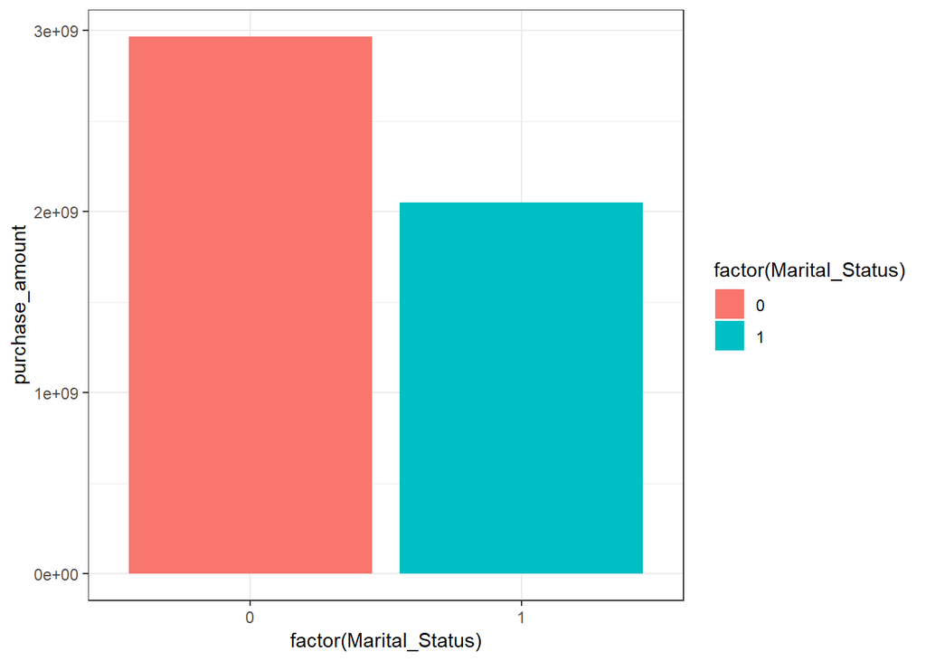

```r
bf %>% group_by(Marital_Status) %>% summarize(purchase_amount = sum(as.numeric(Purchase))) %>% ggplot(mapping = aes(x = factor(Marital_Status), y = purchase_amount, fill = factor(Marital_Status))) + geom_col() + theme_bw()
```

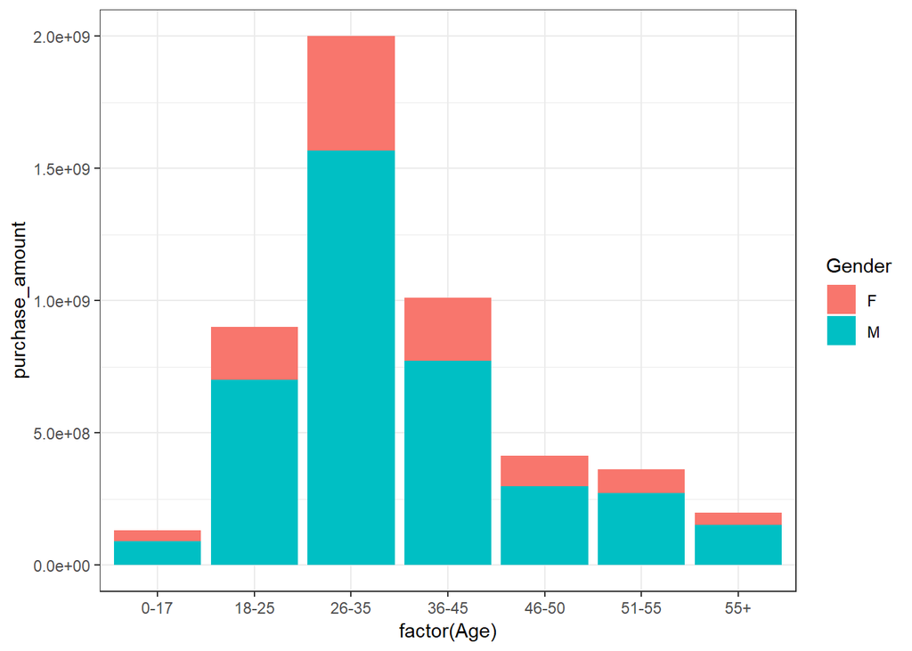

```r
attach(BlackFriday)

BlackFriday  %>% group_by(Age, Gender) %>% summarize(purchase_amount = sum(as.numeric(Purchase))) %>% ggplot(mapping = aes(x = factor(Age), y = purchase_amount, fill = Gender)) + geom_col() + theme_bw()
```

```r
temp<-subset(bf, !duplicated(Occupation))
temp1<-temp$Occupation
temp1
```

```
##  [1] 10 16 15  7 20  9  1 12 17  0  3  4 11  8 19  2 18  5 14 13  6
```

```r
tab<-table(temp1)
tab
```

```
## temp1
##  0  1  2  3  4  5  6  7  8  9 10 11 12 13 14 15 16 17 18 19 20
##  1  1  1  1  1  1  1  1  1  1  1  1  1  1  1  1  1  1  1  1  1
```

From this we can see there are 21 occupations. Now let’s create a graph depending on the occupations.

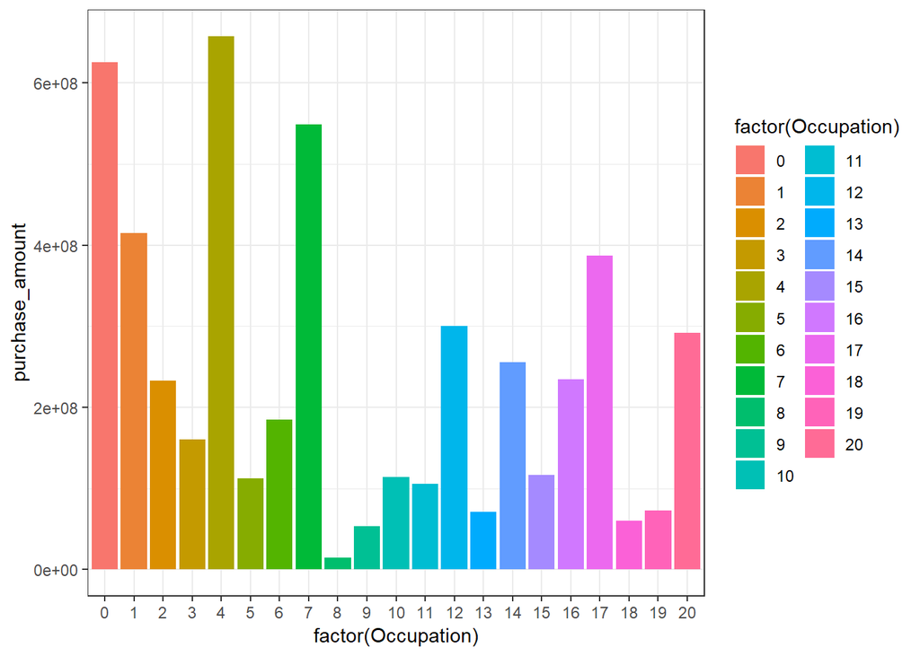

```r
data3 <- bf %>% group_by(Occupation) %>% summarize(purchase_amount = sum(as.numeric(Purchase)))
ggplot(data3, mapping = aes(x = factor(Occupation), y = purchase_amount, fill = factor(Occupation))) + geom_col() + theme_bw()
```

LINEAR REGRESSION :

```r
str(bf)
```

```
## 'data.frame':    537577 obs. of  12 variables:
##  $ User_ID                   : int  1000001 1000001 1000001 1000001 1000002 1000003 1000004 1000004 1000004 1000005 ...
##  $ Product_ID                : Factor w/ 3623 levels "P00000142","P00000242",..: 671 2375 851 827 2733 1830 1744 3319 3597 2630 ...
##  $ Gender                    : Factor w/ 2 levels "F","M": 1 1 1 1 2 2 2 2 2 2 ...
##  $ Age                       : Factor w/ 7 levels "0-17","18-25",..: 1 1 1 1 7 3 5 5 5 3 ...
##  $ Occupation                : int  10 10 10 10 16 15 7 7 7 20 ...
##  $ City_Category             : Factor w/ 3 levels "A","B","C": 1 1 1 1 3 1 2 2 2 1 ...
##  $ Stay_In_Current_City_Years: Factor w/ 5 levels "0","1","2","3",..: 3 3 3 3 5 4 3 3 3 2 ...
##  $ Marital_Status            : int  0 0 0 0 0 0 1 1 1 1 ...
##  $ Product_Category_1        : int  3 1 12 12 8 1 1 1 1 8 ...
##  $ Product_Category_2        : int  NA 6 NA 14 NA 2 8 15 16 NA ...
##  $ Product_Category_3        : int  NA 14 NA NA NA NA 17 NA NA NA ...
##  $ Purchase                  : int  8370 15200 1422 1057 7969 15227 19215 15854 15686 7871 ...
```

```r
model<-lm(Purchase~. -User_ID -Product_ID, data=bf)
summary(model)
```

```
##
## Call:
## lm(formula = Purchase ~ . - User_ID - Product_ID, data = bf)
##
## Residuals:
##      Min       1Q   Median       3Q      Max
## -11113.7  -2836.5   -438.2   2777.9  19943.5
##
## Coefficients:
##                               Estimate Std. Error  t value Pr(>|t|)
## (Intercept)                  11475.589     85.853  133.666  < 2e-16 ***
## GenderM                        319.064     27.718   11.511  < 2e-16 ***
## Age18-25                       422.370     72.407    5.833 5.45e-09 ***
## Age26-35                       544.708     70.396    7.738 1.02e-14 ***
## Age36-45                       679.366     72.446    9.378  < 2e-16 ***
## Age46-50                       700.330     80.397    8.711  < 2e-16 ***
## Age51-55                      1053.107     82.387   12.782  < 2e-16 ***
## Age55+                         906.301     91.983    9.853  < 2e-16 ***
## Occupation                       7.150      1.788    3.998 6.38e-05 ***
## City_CategoryB                 200.741     29.121    6.893 5.47e-12 ***
## City_CategoryC                 833.828     30.650   27.205  < 2e-16 ***
## Stay_In_Current_City_Years1    111.132     36.783    3.021  0.00252 **
## Stay_In_Current_City_Years2    212.668     40.811    5.211 1.88e-07 ***
## Stay_In_Current_City_Years3     64.531     41.508    1.555  0.12002
## Stay_In_Current_City_Years4+   151.087     42.837    3.527  0.00042 ***
## Marital_Status                 -37.609     24.864   -1.513  0.13039
## Product_Category_1            -828.028      5.151 -160.749  < 2e-16 ***
## Product_Category_2              25.370      3.402    7.457 8.90e-14 ***
## Product_Category_3              72.698      3.310   21.960  < 2e-16 ***
## ---
## Signif. codes:  0 '***' 0.001 '**' 0.01 '*' 0.05 '.' 0.1 ' ' 1
##
## Residual standard error: 4630 on 164259 degrees of freedom
##   (373299 observations deleted due to missingness)
## Multiple R-squared:  0.1701, Adjusted R-squared:   0.17
## F-statistic:  1870 on 18 and 164259 DF,  p-value: < 2.2e-16
```

As from above, we find out marital status is insignicifant, we remove the column.

```r
model1<-lm(Purchase~. -User_ID -Product_ID -Marital_Status, data=bf)
summary(model1)
```

```
##
## Call:
## lm(formula = Purchase ~ . - User_ID - Product_ID - Marital_Status,
##     data = bf)
##
## Residuals:
##      Min       1Q   Median       3Q      Max
## -11123.7  -2837.2   -438.4   2779.5  19950.4
##
## Coefficients:
##                               Estimate Std. Error  t value Pr(>|t|)
## (Intercept)                  11476.137     85.853  133.673  < 2e-16 ***
## GenderM                        319.478     27.717   11.526  < 2e-16 ***
## Age18-25                       414.456     72.218    5.739 9.54e-09 ***
## Age26-35                       529.630     69.687    7.600 2.97e-14 ***
## Age36-45                       664.797     71.803    9.259  < 2e-16 ***
## Age46-50                       672.740     78.301    8.592  < 2e-16 ***
## Age51-55                      1025.900     80.400   12.760  < 2e-16 ***
## Age55+                         883.183     90.705    9.737  < 2e-16 ***
## Occupation                       7.146      1.788    3.996 6.43e-05 ***
## City_CategoryB                 200.009     29.117    6.869 6.48e-12 ***
## City_CategoryC                 832.869     30.644   27.179  < 2e-16 ***
## Stay_In_Current_City_Years1    110.788     36.783    3.012 0.002596 **
## Stay_In_Current_City_Years2    212.666     40.811    5.211 1.88e-07 ***
## Stay_In_Current_City_Years3     64.622     41.508    1.557 0.119508
## Stay_In_Current_City_Years4+   151.556     42.836    3.538 0.000403 ***
## Product_Category_1            -828.030      5.151 -160.749  < 2e-16 ***
## Product_Category_2              25.378      3.402    7.459 8.74e-14 ***
## Product_Category_3              72.692      3.310   21.958  < 2e-16 ***
## ---
## Signif. codes:  0 '***' 0.001 '**' 0.01 '*' 0.05 '.' 0.1 ' ' 1
##
## Residual standard error: 4630 on 164260 degrees of freedom
##   (373299 observations deleted due to missingness)
## Multiple R-squared:  0.1701, Adjusted R-squared:   0.17
## F-statistic:  1980 on 17 and 164260 DF,  p-value: < 2.2e-16
```